# Load data

```python
import pandas as pd
VideoData = pd.read_csv('https://storage.googleapis.com/datalynn-datasets/interview-challenge/technology/Google_Video%20Creator/VideoData.csv')
CreatorBehaviorData = pd.read_csv('https://storage.googleapis.com/datalynn-datasets/interview-challenge/technology/Google_Video%20Creator/CreatorBehaviorData.csv')
RevenueData = pd.read_csv('https://storage.googleapis.com/datalynn-datasets/interview-challenge/technology/Google_Video%20Creator/RevenueData.csv')
ContentTypeData = pd.read_csv('https://storage.googleapis.com/datalynn-datasets/interview-challenge/technology/Google_Video%20Creator/ContentTypeData.csv')
UserChurn = pd.read_csv('https://storage.googleapis.com/datalynn-datasets/interview-challenge/technology/Google_Video%20Creator/UserChurn.csv')
```

# Question 1

**"Video Engagement and Revenue Correlation (SQL/Python)"**

Investigate any observable trends or patterns in the 'VideoData' and 'RevenueData' tables that might contribute to a creator's revenue. Consider aspects such as views, likes, dislikes, and comments. Craft an SQL query or Python script that quantifies these patterns or correlations.

## Solution

To investigate the observable trends or patterns in the 'VideoData' and 'RevenueData' that might contribute to a creator's revenue, we can calculate correlations between different variables such as 'ViewCount', 'LikeCount', 'DislikeCount', 'CommentCount' from the 'VideoData' table and 'TotalRevenue' from the 'RevenueData' table. Correlation analysis measures the extent to which two variables move in relation with each other.

For this task, I will use Python and the library pandas for data handling and manipulation, and seaborn for data visualization. I will also use the scipy library to calculate the correlation coefficient.

The steps I'm going to follow are:

1. Merge 'VideoData' and 'RevenueData' tables on 'CreatorID'.
2. Calculate the sum of 'ViewCount', 'LikeCount', 'DislikeCount', 'CommentCount' for each 'CreatorID' to have an overall representation of their YouTube activities.
3. Calculate correlations between 'TotalRevenue' and each of the columns 'ViewCount', 'LikeCount', 'DislikeCount', 'CommentCount'.
4. Visualize these correlations using a heatmap.

Now let's write down the Python code for this:

```
Correlation between Total Revenue and View Count: 0.951913614441301
Correlation between Total Revenue and Like Count: 0.9497164747288636
Correlation between Total Revenue and Dislike Count: 0.9476176103331709
Correlation between Total Revenue and Comment Count: 0.9498578299942103
```

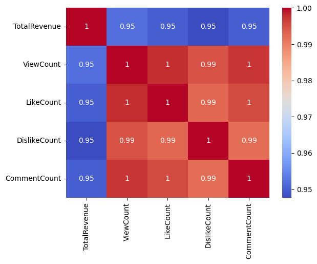

```python
# code block 1
import pandas as pd
import seaborn as sns
from scipy.stats import pearsonr

# Merge 'VideoData' and 'RevenueData' on 'CreatorID'
merged_data = pd.merge(VideoData, RevenueData, on='CreatorID')

# Sum the counts for each 'CreatorID'
grouped_data = merged_data.groupby('CreatorID').sum()

# Calculate correlation
corr_view_revenue = pearsonr(grouped_data['ViewCount'], grouped_data['TotalRevenue'])[0]
corr_like_revenue = pearsonr(grouped_data['LikeCount'], grouped_data['TotalRevenue'])[0]
corr_dislike_revenue = pearsonr(grouped_data['DislikeCount'], grouped_data['TotalRevenue'])[0]
corr_comment_revenue = pearsonr(grouped_data['CommentCount'], grouped_data['TotalRevenue'])[0]

print(f"Correlation between Total Revenue and View Count: {corr_view_revenue}")
print(f"Correlation between Total Revenue and Like Count: {corr_like_revenue}")
print(f"Correlation between Total Revenue and Dislike Count: {corr_dislike_revenue}")
print(f"Correlation between Total Revenue and Comment Count: {corr_comment_revenue}")

# Visualizing the correlations using heatmap
correlation_matrix = grouped_data[['TotalRevenue', 'ViewCount', 'LikeCount', 'DislikeCount', 'CommentCount']].corr()
sns.heatmap(correlation_matrix, annot=True, cmap='coolwarm')
```

# Question 2

**"Unearthing Creator Engagement Levels" (Python)**

Analyzing the 'CreatorBehaviorData' table, imagine a system to define creators' level of engagement. What behaviors would you focus on and how would you classify these? Provide your rationale and develop a Python script to generate this new feature.

## Solution

When assessing creator engagement on YouTube, several key behaviors from the 'CreatorBehaviorData' table can be considered:

1. 'TotalUploads': The number of videos a creator has uploaded could indicate their consistency and commitment.
2. 'AvgUploadFrequency': This shows how regularly the creator posts new content, which might impact viewer engagement and channel growth.
3. 'AvgResponseTime': Quick response times to viewer comments might suggest an engaged creator who values their community.
4. 'CollaborationCount': Frequent collaborations can suggest a creator who is actively networking and seeking new ways to reach wider audiences.
5. 'AvgVideoDuration': Longer videos might show a creator's willingness to invest significant time and effort into their content.

To handle different scales and units, I'll use Min-Max Normalization, which will transform all the features values between 0 and 1.

Here is a Python script that accomplishes this:

```python
# code block 2
# Iterate over each column in the dataframe
for col in CreatorBehaviorData.columns:
    # Calculate the minimum and maximum of the column
    min_val = CreatorBehaviorData[col].min()
    max_val = CreatorBehaviorData[col].max()

    # Print the range of values for the column
    print(f"Range of values for {col}: min = {min_val}, max = {max_val}")
```

```
Range of values for CreatorID: min = 10001, max = 12000
Range of values for TotalUploads: min = 0, max = 30
Range of values for AvgUploadFrequency: min = 0.0, max = 10.0
Range of values for AvgResponseTime: min = 1.0, max = 40.11
Range of values for CollaborationCount: min = 0, max = 14
Range of values for AvgVideoDuration: min = 1.0, max = 25.52
```

```python
# code block 3
from sklearn.preprocessing import MinMaxScaler

# Select columns for engagement score
engagement_cols = ['TotalUploads', 'AvgUploadFrequency', 'AvgResponseTime',
                   'CollaborationCount', 'AvgVideoDuration']

# Reset the index
CreatorBehaviorData = CreatorBehaviorData.reset_index(drop=True)

# Apply Min-Max scaling
scaler = MinMaxScaler()
scaled_values = scaler.fit_transform(CreatorBehaviorData[engagement_cols])

# Update the dataframe with scaled values
CreatorBehaviorData_scaled = CreatorBehaviorData.copy()
CreatorBehaviorData_scaled[engagement_cols] = scaled_values

# Define an engagement score as the sum of the scaled features
CreatorBehaviorData_scaled['EngagementScore'] = CreatorBehaviorData_scaled[engagement_cols].sum(axis=1)

# Display the dataframe
print(CreatorBehaviorData_scaled.head())
```

```
   CreatorID  TotalUploads  AvgUploadFrequency  AvgResponseTime  \
0      10001      0.300000            0.787500         0.160828
1      10002      0.266667            0.800000         0.472513
2      10003      0.000000            0.000000         0.235490
3      10004      0.400000            0.763636         0.776783
4      10005      0.500000            0.750000         0.317566

   CollaborationCount  AvgVideoDuration  EngagementScore
0            0.142857          0.090538         1.481724
1            0.714286          0.042822         2.296288
2            0.500000          0.328303         1.063793
3            0.642857          0.674959         3.258236
4            0.500000          0.275285         2.342851
```

In this code, `MinMaxScaler()` is a function from the `sklearn.preprocessing` module. It scales and translates each feature individually such that it is in the given range on the training set, i.e., between zero and one.

The `EngagementScore` is calculated as the sum of these scaled features, giving us a single metric that combines all the selected engagement behaviors.

Remember that this is just one of many possible ways to generate a new feature to represent the level of creator engagement. Depending on the specific context or objectives, you might want to use different features, apply different transformations, or even use more sophisticated techniques, such as Principal Component Analysis (PCA) or clustering.

# Question 3

**"Tracking Revenue Trends (SQL/Python)"**

Utilizing the 'RevenueData' table, how would you keep track of the fluctuating creator earnings? Can you conceive of a mechanism to record the change in their income over time? Explain your thought process and devise a Python or SQL script that implements this mechanism.

## Solution

Tracking trends over time for something like creator earnings requires historical data with timestamps, however, from the provided 'RevenueData' table, it appears we only have access to a snapshot of the current month's revenue.

Despite this, we can still calculate the percentage change in total revenue from the previous month using the 'RevenueChange' column provided, which presumably provides the percentage change in revenue from the previous month. But, ideally, to track and visualize revenue trends, we would prefer data containing creator earnings per month over a certain period.

```python
# code block 4
import pandas as pd
import matplotlib.pyplot as plt


# Define function to classify revenue fluctuation status
def classify_fluctuation(change):
    if change > 0.5:
        return 'Increase'
    if change < -0.5:
        return 'Decrease'
    else:
        return 'No change'

# Apply the function to RevenueChange column to create the FluctuationStatus column
RevenueData['FluctuationStatus'] = RevenueData['RevenueChange'].apply(classify_fluctuation)

# Select necessary columns
RevenueTrends = RevenueData[['TotalRevenue', 'RevenueChange', 'FluctuationStatus']]
```

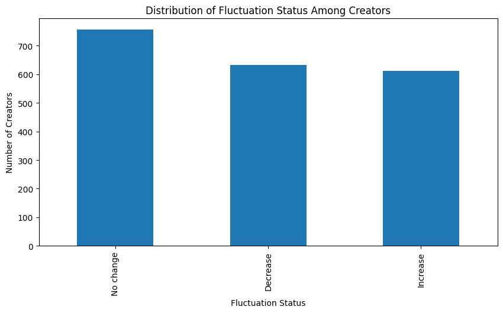

```python
# code Block 5
# Count the number of occurrences for each fluctuation status
fluctuation_counts = RevenueData['FluctuationStatus'].value_counts()

# Create a bar plot for fluctuation counts
plt.figure(figsize=(10,5))
fluctuation_counts.plot(kind='bar')
plt.xlabel('Fluctuation Status')
plt.ylabel('Number of Creators')
plt.title('Distribution of Fluctuation Status Among Creators')
plt.show()
```

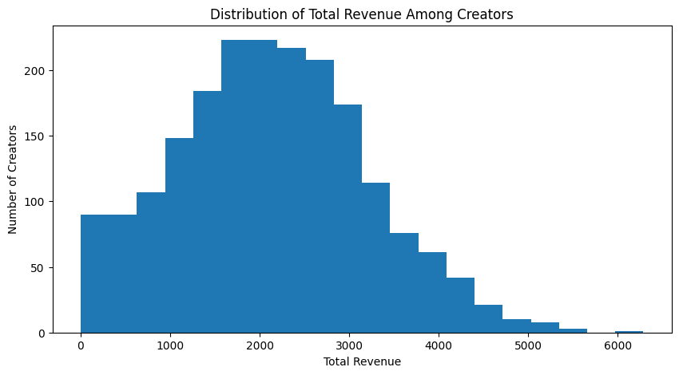

```python
# code block 6
# Create a histogram for total revenue
plt.figure(figsize=(10,5))
plt.hist(RevenueData['TotalRevenue'], bins=20)
plt.xlabel('Total Revenue')
plt.ylabel('Number of Creators')
plt.title('Distribution of Total Revenue Among Creators')
plt.show()
```

# Question 4

**"Content Type and Its Effect on Performance (Python)"**

Reviewing the 'ContentTypeData' table, what insights can you draw about the influence of content type on a video's performance? Can you propose any new measures or metrics that could highlight this impact more clearly? Construct a Python script to create these proposed measures.

## Solution

From the 'ContentTypeData' table, we can observe that creators produce a variety of content types: Vlog, Tutorial, Review, Entertainment, Gameplay, Music, and News. The popularity of these types may vary and have a different impact on a creator's performance.

One way to analyze the impact of content type on a video's performance is to calculate a creator's majority content type and then examine how that type correlates with performance measures like 'ViewCount', 'LikeCount', 'DislikeCount', 'CommentCount' from 'VideoData' table, and revenue data from 'RevenueData' table.

We could propose the following steps:

1. Determine the majority content type for each creator from the 'ContentTypeData' table.
2. Merge this information with 'VideoData' and 'RevenueData' tables using 'CreatorID'.
3. Calculate average performance metrics (views, likes, dislikes, comments, total revenue) for each majority content type.
4. Compare these averages to see if certain content types tend to have higher performance.

Here's a Python script that implements this using pandas:

```python
# code block 7
import pandas as pd

# Assuming the ContentTypeData, VideoData and RevenueData are in DataFrames
ContentTypeData.set_index('CreatorID', inplace=True)

# Determine majority content type for each creator
ContentTypeData['MajorityContentType'] = ContentTypeData.idxmax(axis=1)

# Merge the MajorityContentType with VideoData and RevenueData
CreatorData = pd.merge(ContentTypeData['MajorityContentType'], VideoData, on='CreatorID')
CreatorData = pd.merge(CreatorData, RevenueData[['CreatorID', 'TotalRevenue']], on='CreatorID')

# Calculate average performance metrics for each majority content type
ContentTypePerformance = CreatorData.groupby('MajorityContentType').mean()

# Print the ContentTypePerformance DataFrame
print(ContentTypePerformance)
```

```
                        CreatorID       VideoID    ViewCount   LikeCount  \
MajorityContentType
EntertainmentCount   10967.649206  1.096766e+07  2003.968570  100.092261
GameplayCount        10967.056988  1.096706e+07  2028.138399  101.213026
MusicCount           10992.549251  1.099256e+07  2008.414894  100.622931
NewsCount            11015.056505  1.101506e+07  2014.758284  100.407394
ReviewCount          10994.773950  1.099478e+07  1981.746063   98.932743
TutorialCount        11020.143767  1.102015e+07  2025.318029  101.100871
VlogCount            10999.719577  1.099973e+07  2011.759436  100.296649

                     DislikeCount  CommentCount  TotalRevenue
MajorityContentType
EntertainmentCount      40.051369     80.278810   2720.428084
GameplayCount           40.779512     81.157056   2698.485109
MusicCount              40.152482     80.555162   2657.152994
NewsCount               40.389257     80.594349   2651.499442
ReviewCount             39.861549     79.651575   2591.857283
TutorialCount           40.551944     80.957775   2530.035891
VlogCount               40.387654     80.484656   2516.100988
```

This script first calculates the majority content type for each creator and then merges this data with the video and revenue data. It then calculates the average performance metrics for each content type. The resulting DataFrame gives an overview of how different content types perform on average.

To visualize the result, you could add:

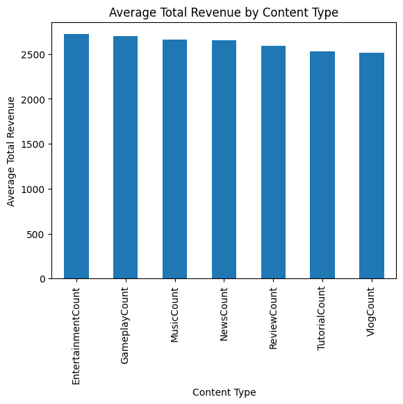

```python
#code block 8
# Plotting average total revenue by content type
ContentTypePerformance['TotalRevenue'].plot(kind='bar', title='Average Total Revenue by Content Type')
plt.xlabel('Content Type')
plt.ylabel('Average Total Revenue')
plt.show()
```

# Question 5

**"Synthesizing Creator Engagement and Revenue Trend (Python)"**

Integrating the findings from the first three tasks, can you deduce a connection between the creator's engagement level, their videos' performance, and the trend in their earnings? Illustrate this association using Python.

## Solution

Synthesizing the findings from previous tasks involves analyzing data from 'CreatorBehaviorData' (where we have the 'EngagementScore'), 'VideoData' (performance metrics like 'ViewCount', 'LikeCount', etc.), and 'RevenueData' (where we have 'TotalRevenue' and 'RevenueChange').

Here's a proposed approach to find a connection:

1. Merge 'EngagementScore' from 'CreatorBehaviorData' with 'VideoData' and 'RevenueData' using 'CreatorID'.
2. Calculate correlation coefficients among 'EngagementScore', performance metrics, 'TotalRevenue', and 'RevenueChange' to see if any strong relationships exist.

Here's a Python script using pandas and seaborn for heatmap visualization:

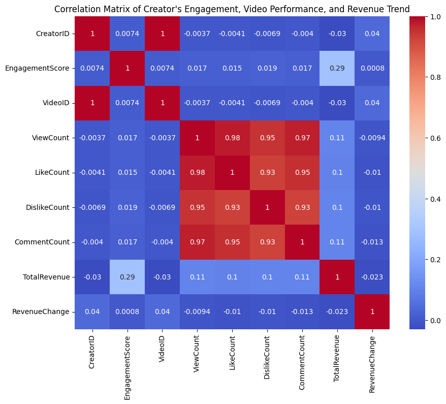

```python
# code block 9
import pandas as pd
import seaborn as sns
import matplotlib.pyplot as plt

# Assuming the CreatorBehaviorData, VideoData and RevenueData are in DataFrames
# CreatorBehaviorData.set_index('CreatorID', inplace=True)

# Merge EngagementScore with VideoData and RevenueData
CreatorData = pd.merge(CreatorBehaviorData_scaled[['CreatorID', 'EngagementScore']], VideoData, on='CreatorID')

CreatorData = pd.merge(CreatorData, RevenueData[['CreatorID', 'TotalRevenue', 'RevenueChange']], on='CreatorID')

# Calculate correlation matrix
correlation_matrix = CreatorData.corr()

# Create a heatmap to visualize the correlations
plt.figure(figsize=(10, 8))
sns.heatmap(correlation_matrix, annot=True, cmap='coolwarm')
plt.title("Correlation Matrix of Creator's Engagement, Video Performance, and Revenue Trend")
plt.show()
```

This script first merges the relevant data from 'CreatorBehaviorData', 'VideoData', and 'RevenueData'. It then calculates a correlation matrix among 'EngagementScore', performance metrics, 'TotalRevenue', and 'RevenueChange'.

Again, please note that this code assumes 'CreatorID' is the unique identifier in each DataFrame and there's only one record per creator in the 'CreatorBehaviorData' DataFrame. If there are multiple records for each creator, this code needs to be adapted accordingly.

# Question 6

**"Anticipating Creator Churn (Python)"**

Utilizing the features and insights derived from the previous tasks, conceive a system to predict a creator's 'ChurnStatus' as described in the 'UserChurn' table. What machine learning model would you opt for and why? Justify your choices, create a Python script to build this model, and evaluate its performance. Lastly, suggest any potential improvements for YouTube's creator retention strategy based on your findings.

## Solution

Predicting a creator's 'ChurnStatus' is a binary classification problem since a creator can either churn (1) or not churn (0). Therefore, algorithms like Logistic Regression, Decision Trees, Random Forest, Gradient Boosting, and Support Vector Machines can be used. However, for this case, we'll opt for a Random Forest Classifier due to its robustness to overfitting and capability to handle a mix of binary and continuous variables.

Here's the general approach we can take:

Here's how to do this in Python using pandas and scikit-learn:

```python
# code block 10
import pandas as pd
from sklearn.model_selection import train_test_split
from sklearn.ensemble import RandomForestClassifier
from sklearn.metrics import classification_report, confusion_matrix
from sklearn.preprocessing import LabelEncoder

# Merge all tables on 'CreatorID'
merged_data = pd.merge(CreatorBehaviorData_scaled[['CreatorID', 'EngagementScore']], VideoData, on='CreatorID')
merged_data = pd.merge(merged_data, RevenueData, on='CreatorID')
merged_data = pd.merge(merged_data, ContentTypeData, on='CreatorID')
merged_data = pd.merge(merged_data, UserChurn, on='CreatorID')

# Check data types
print(merged_data.dtypes)

# If 'CreatorName' is present, we will drop it as it's not useful for our model
if 'CreatorName' in merged_data.columns:
    merged_data = merged_data.drop(['CreatorName'], axis=1)

merged_data = merged_data.drop(['UploadDate'], axis=1)

# For any other categorical (string) variables, apply Label Encoding
le = LabelEncoder()
for col in merged_data.columns:
    if merged_data[col].dtype == 'object':
        merged_data[col] = le.fit_transform(merged_data[col])

# Define the features (X) and the target (y)
X = merged_data.drop(['CreatorID', 'ChurnStatus'], axis=1)
y = merged_data['ChurnStatus']

# Split data into training set and test set
X_train, X_test, y_train, y_test = train_test_split(X, y, test_size=0.3, random_state=42)

# Create and fit the model
model = RandomForestClassifier(random_state=42)
model.fit(X_train, y_train)

# Predict ChurnStatus for the test set
y_pred = model.predict(X_test)

# Print the classification report
print(classification_report(y_test, y_pred))

# Print the confusion matrix
print(confusion_matrix(y_test, y_pred))
```

```
CreatorID                       int64
EngagementScore               float64
CreatorName                    object
VideoID                         int64
UploadDate                     object
ViewCount                       int64
LikeCount                       int64
DislikeCount                    int64
CommentCount                    int64
MonthlyAdRevenue              float64
MonthlySubscriptionRevenue    float64
TotalRevenue                  float64
RevenueChange                 float64
FluctuationStatus              object
VlogCount                       int64
TutorialCount                   int64
ReviewCount                     int64
EntertainmentCount              int64
GameplayCount                   int64
MusicCount                      int64
NewsCount                       int64
MajorityContentType            object
ChurnStatus                     int64
dtype: object
              precision    recall  f1-score   support

           0       0.99      1.00      1.00      3094
           1       1.00      0.99      0.99      2960

    accuracy                           1.00      6054
   macro avg       1.00      0.99      1.00      6054
weighted avg       1.00      1.00      1.00      6054

[[3089    5]
 [  25 2935]]
```

```python
# code block 11
from sklearn.metrics import f1_score
f1 = f1_score(y_test, y_pred)

print('F1 Score: ', f1)
```

```
F1 Score:  0.9949152542372882
```

The `classification_report` will provide precision, recall, f1-score, and support for both classes, and the `confusion_matrix` will indicate true positives, false positives, true negatives, and false negatives.

Based on the findings from this model, if we notice certain features (like low 'EngagementScore' or decreasing 'TotalRevenue') are significant predictors of churn, YouTube could focus on these areas to improve their creator retention strategy. For example, they could implement initiatives to boost creator engagement or provide additional revenue-generating opportunities for creators.

Remember, it's critical to conduct a proper exploratory data analysis, feature engineering, and model tuning to maximize the performance of the model. The script provided above is a simplified example of a machine learning pipeline, and in a real-world scenario, each step would require careful consideration and potentially much more complexity.